# The Economic and Health Impact of Severe Weather Events in the United States Over the Past Twenty Years

Author: Harold L Trammel

## Synopsis

The U.S. National Oceanic and Atmospheric Administration (NOAA) collects storm-related data in their Storm Database. These data are collected from a wide range of sources across the United States. Two important facets of the data collected are health impact and economic impact. Data from this database were analyzed for for the past twenty years (1994-2014) with particular focus on health and economic impact of storms.

Thunderstorm Winds were the most common storm event type over the twenty years. This was also the most common cause of economic loss. Over the twenty year period, thunderstrom winds accounted for more that 1 billon dollars in damages. Tornados were the second most common cause of damages but the primary cause of human health effects. Tornados were far more likely to cause human deaths and injuries than the other storm event types. Flooding (flash floods and general flooding) caused almost as much damage as thunderstorm winds. Thunderstorm related events (wind, lightening, and hail) combined appeared to be a common cause of both damaage and human effects.

## Data Processing

The first steps in this research were to:

1. Download the provided Storm Database
2. Clean and tidy the data needed for the desired analysis

```r
require(plyr)
require(dplyr)
```

```r
require(ggplot2)
require(lubridate)
require(stringr)
require(qdap)
if(!file.exists("./data")) {dir.create("./data")}
fileURL <- "https://d396qusza40orc.cloudfront.net/repdata%2Fdata%2FStormData.csv.bz2"
dataFile <- "repdata-data-StormData.csv.bz2"
dataRDS <- "./data/storm.rds"

# extract data from file and store in RDS file
if (!file.exists(dataFile)) {
    if (Sys.info()['sysname'] == "Windows") {
        # needed for my Windows PC
        download.file(fileURL, destfile=dataFile)
    } else {
        # ne landeded for my Mac
        download.file(fileURL, destfile=dataFile, method = "curl", mode = "wb")
    }
    storm_df <- read.csv(bzfile(dataFile), stringsAsFactors = FALSE)
    saveRDS(storm_df, dataRDS)
} else if (!file.exists(dataRDS)) {
    storm_df <- read.csv(bzfile(dataFile), stringsAsFactors = FALSE)
    saveRDS(storm_df, dataRDS)
}

# check to see if data frame loaded already
if (exists("storm_df") == FALSE) {
    storm_df <- readRDS(dataRDS)
}
```

After reviewing the data structures and contents of the data provided, I decided to extract only the columns and rows needed for my analysis. These were:

- BGN_DATE
- EVTYPE
- FATALITIES
- INJURIES
- PROPDMG
- PROPDMGEXP
- CROPDMG
- CROPDMGEXP

```r
# select only the needed columns
df <- select(storm_df, one_of(c("BGN_DATE", "EVTYPE", "FATALITIES","INJURIES",
"PROPDMG", "PROPDMGEXP", "CROPDMG", "CROPDMGEXP")))
# function to convert unit abbreviations to numeric values
damageUnit <- function (cv) {
    for (i in cv) {
        if (i == "B") { return (1000000000) }
        else if (i == "M") { return (1000000) }
        else if (i == "K") { return (1000) }
        else return (1)
    }
}
# general conversions to make things better
df$EVTYPE <- str_to_title(as.character(df$EVTYPE))
df$BGN_DATE <- as.character.Date(df$BGN_DATE)
df$BGN_DATE <- dmy_hms(df$BGN_DATE)
# filter for only past twenty years data
df <- filter (df, year(df$BGN_DATE) >= 1994 & year(df$BGN_DATE) <= 2014 )
# filter for only rows with human and economic impact
df <- filter(df, FATALITIES > 0 | INJURIES > 0 | PROPDMG > 0 | CROPDMG > 0)
# add new column to hold calculated values
df <- mutate (df, humEffect = FATALITIES + INJURIES)
df <- mutate (df, damage = (PROPDMG * damageUnit(PROPDMGEXP)) +
                  (CROPDMG * damageUnit(CROPDMGEXP)))
```

Because the data were obtained from such a wide range of sources over the past 65 years, the EVTYPE values were frequently inconsistent. As part of the preliminary analysis, I identified the most commonly occuring EVTYPE values for the past twenty years and then strived to make sure that these EVTYPE records were cleaned.

```r
# remove leading and laging spaces
df$EVTYPE <- Trim(df$EVTYPE)

# MISCELLANOUS ##########################################
# Debris Flow
df$EVTYPE <- gsub("[ a-zA-Z/]*[s]*[/]*slide", "Debris Flow", df$EVTYPE, ignore.case = T)
# Dense Fog
df$EVTYPE <- gsub("[ a-zA-Z/]*[s]*[/]*Dense Fog", "Dense Fog", df$EVTYPE)
# Dense Smoke [NO CHANGE]

# WIND AND RAIN RELATED ######################################
# Wind
df$EVTYPE <- gsub("W[i]*n[s|d][s]*", "Wind", df$EVTYPE)
df$EVTYPE <- gsub("Wind[ a-zA-Z/0-9\\(\\)\\.]*", "Wind", df$EVTYPE)
# High Wind
df$EVTYPE <- mgsub(c("Gradient Wind","Extreme Wind"
                    ,"Storm Force Wind", "Strong Wind"
                    ,"Gusty Wind")
                  ,c("High Wind"), df$EVTYPE)
# Thunderstorm Wind
df$EVTYPE <- gsub("Tstm", "Thunderstorm", df$EVTYPE)
df$EVTYPE <- gsub("T[h]*u[n]*[d]*e[e]*r[s]*t[or|ro]*m[s|w]*", "Thunderstorm", df$EVTYPE)
df$EVTYPE <- gsub("[(]*[a-zA-Z]*[0-9]+([ ]*Mph)*[)]*", " ", df$EVTYPE)
df$EVTYPE <- gsub("Thunderstorm Wind[\\. a-zA-Z/]*", "Thunderstorm Wind", df$EVTYPE)
# Hail
df$EVTYPE <- gsub("Hail([ ]*[0-9]*|[ ]*/[a-zA-Z]*)", "Hail", df$EVTYPE)
df$EVTYPE <- gsub("[a-zA-Z /]*Hail", "Hail", df$EVTYPE)
# Lightning
df$EVTYPE <- gsub("Lightning[a-zA-Z/ \\.]*", "Lightning", df$EVTYPE)
df$EVTYPE <- gsub("[a-zA-Z/ ]*Lightning", "Lightning", df$EVTYPE)
# Heavy Rain
df$EVTYPE <- gsub("[a-zA-Z ]*Rain/Winter Weather", "WW", df$EVTYPE)
df$EVTYPE <- gsub("Heavy Rain[/a-zA-Z ]*)*", "Heavy Rain", df$EVTYPE)
df$EVTYPE <- mgsub(c("Excessive Rainfall", "Unseasonal Rain")
                 , c("Heavy Rain"), df$EVTYPE)

# HEAT RELATED ################################################
# Drought [NO CHANGE]
df$EVTYPE <- gsub("Drought[-/a-zA-Z ]*", "Drought", df$EVTYPE)
df$EVTYPE <- gsub("[/a-zA-Z ]*Drought", "Drought", df$EVTYPE)
# Dust Devil
df$EVTYPE <- gsub("Dust Devil Waterspout","Dust Devil", df$EVTYPE)
# Dust Storm [NO CHANGE]
# Excessive Heat
df$EVTYPE <- gsub("[ a-zA-Z/]* Heat", "Excessive Heat", df$EVTYPE)
# Heat
df$EVTYPE <- gsub("Heat [a-zA-Z/ ]+", "Heat", df$EVTYPE)

# FLOOD RELATED ###############################################
# Coastal Flooding
df$EVTYPE <- gsub("(Coastal|Cstl|Tidal) Flood(ing)*", "CFLD", df$EVTYPE)
df$EVTYPE <- gsub("[ a-zA-Z/]*[s]*[/]*Coastal Flood", "CFLD", df$EVTYPE)
df$EVTYPE <- gsub("Coastal Flood[/]*[a-zA-A /]+", "CFLD", df$EVTYPE)
# Flash flood
df$EVTYPE <- mgsub(c("Flash Flood/Flood","Flood/Flash Flood"), "Flood", df$EVTYPE)
df$EVTYPE <- gsub("Flash (Fl[o]+d)(s|ing)*", "FF", df$EVTYPE)
df$EVTYPE <- gsub("Flash Flood[ a-zA-Z/]+", "FF", df$EVTYPE)
df$EVTYPE <- gsub("[ a-zA-Z/]+Flash Flood", "FF", df$EVTYPE)
# Flood
df$EVTYPE <- gsub("Flood(s|in[g]*)*", "Flood", df$EVTYPE)
df$EVTYPE <- gsub("Flood/*[ a-zA-Z/(&]*", "Flood", df$EVTYPE)
df$EVTYPE <- gsub("Thunder[a-zA-Z/ ]+ Flood", "Flood", df$EVTYPE)
df$EVTYPE <- gsub("[a-zA-Z/ ]+Flood", "Flood", df$EVTYPE)
#---------------
df$EVTYPE <- mgsub(c("CFLD","FF")
                   ,c("Coastal Flood","Flash Flood"), df$EVTYPE)
###############################################################

# #### WINTER #############################################
# Avalance
df$EVTYPE <- gsub("([ a-zA-Z/]*)*Avalanche", "Avalanche", df$EVTYPE)
# Blizzard
df$EVTYPE <- gsub("Blizzard[-/a-zA-Z ]*", "Blizzard", df$EVTYPE)
df$EVTYPE <- gsub("[/a-zA-Z ]*Blizzard", "Blizzard", df$EVTYPE)
# Cold/Wind Chill
df$EVTYPE <- mgsub(c("Fog And Cold","Cold/Wind Chill"
                     ,"High Wind/Cold","Cold/Wind")
                   , c("CWC"), df$EVTYPE)
df$EVTYPE <- gsub("Un[a-zA-Z]+ Cold", "CWC", df$EVTYPE)
df$EVTYPE <- gsub("Cold (Temp[a-z]+[s]*|Wave|Weather)+", "CWC", df$EVTYPE)
df$EVTYPE <- gsub("Cold And[a-zA-Z /]+", "CWC", df$EVTYPE)
df$EVTYPE <- gsub("Cold","CWC", df$EVTYPE)
# Extreme Wind Chill <================
df$EVTYPE <- gsub("Ext[a-z]* Cold/Wind Chill", "ECWC", df$EVTYPE)
df$EVTYPE <- gsub("Record Cold/Wind Chill", "ECWC", df$EVTYPE)
df$EVTYPE <- gsub("[/a-zA-Z ]*Extreme Cold", "ECWC", df$EVTYPE)
df$EVTYPE <- gsub("[a-zA-Z ]*(Bitter|Extreme) Wind[ ]*[C|c]?h[a-zA-Z ]+", "ECWC", df$EVTYPE)
#---------------
df$EVTYPE <- mgsub(c("CWC","ECWC")
                   , c("Cold/Wind Chill","Extreme Cold/Wind Chill"), df$EVTYPE)
# Freezing fog
df$EVTYPE <- gsub("[ a-zA-Z/]*[s]*[/]*Freezing Fog", "FZFG", df$EVTYPE)
# Freeze
df$EVTYPE <- gsub("Frost/Freeze","FRZ", df$EVTYPE)
df$EVTYPE <- gsub("(Agricultural|Damaging)*[ ]*Freeze","FRZ", df$EVTYPE)
# Heavy Snow
df$EVTYPE <- gsub("Heavy Snow[-/a-zA-Z ]*", "HSNO", df$EVTYPE)
df$EVTYPE <- gsub("Snow/Heavy Snow", "HSNO", df$EVTYPE)
# Winter Storm
df$EVTYPE <- gsub("Snow[/]*[ ]*Freezing Rain", "WSTRM", df$EVTYPE)
df$EVTYPE <- gsub("Freezing Rain[/]*[ ]*Snow", "WSTRM", df$EVTYPE)
df$EVTYPE <- gsub("Mixed [ a-zA-Z]+", "WSTRM", df$EVTYPE)
df$EVTYPE <- gsub("[a-zA-Z/ ]*Mix", "WSTRM", df$EVTYPE)
df$EVTYPE <- mgsub(c("Snow/Sleet/Freezing Rain"
                    ,"Snow And Ice","Snow/Ice Storm"
                    ,"Falling Snow/Ice","Snow/Sleet"
                    ,"Snow/ Bitter Cold/Wind Chill"
                    ,"([ a-zA-Z]*[ ]*)*Rain/Snow","Snow/ Ice")
                    , c("WSTRM"), df$EVTYPE)
# Winter Weather
df$EVTYPE <- gsub("Light Freezing Rain","WW", df$EVTYPE)
df$EVTYPE <- gsub("Freezing [a-zA-Z/ ]","WW", df$EVTYPE)
df$EVTYPE <- gsub("Snow[/a-zA-Z ]*","WW", df$EVTYPE)
#-----------------
df$EVTYPE <- gsub("FRZ", "Frost/Freeze", df$EVTYPE)
df$EVTYPE <- gsub("FZFG", "Freezing Fog", df$EVTYPE)
df$EVTYPE <- gsub("WW", "Winter Weather", df$EVTYPE)
df$EVTYPE <- gsub("HSNO", "Heavy Snow", df$EVTYPE)
df$EVTYPE <- gsub("WSTRM", "Winter Storm", df$EVTYPE)
###############################################################

# HERE WE GO ROUND IN CIRCLES
# Hurricane/Typhoon
df$EVTYPE <- gsub("Hurricane[a-zA-Z/ ]*", "HTPH", df$EVTYPE)
df$EVTYPE <- gsub("Storm Surge[a-zA-Z/ ]*", "HTPH", df$EVTYPE)
df$EVTYPE <- gsub("HTPH", "Hurricane/Typhoon", df$EVTYPE)
# Funnel cloud
df$EVTYPE <- gsub("Funnel Cloud[a-zA-Z/ ]*", "Funnel Cloud", df$EVTYPE)
df$EVTYPE <- gsub("[a-zA-Z/ ]*Funnel Cloud", "Funnel Cloud", df$EVTYPE)
# Tornado
df$EVTYPE <- gsub("Tornado[es]*( F[0-9])*", "Tornado", df$EVTYPE)
# Tropical Storm
df$EVTYPE <- gsub("Tropical Storm[ a-zA-Z]*", "Tropical Storm", df$EVTYPE)

df$EVTYPE <- Trim(df$EVTYPE)
```

## Results

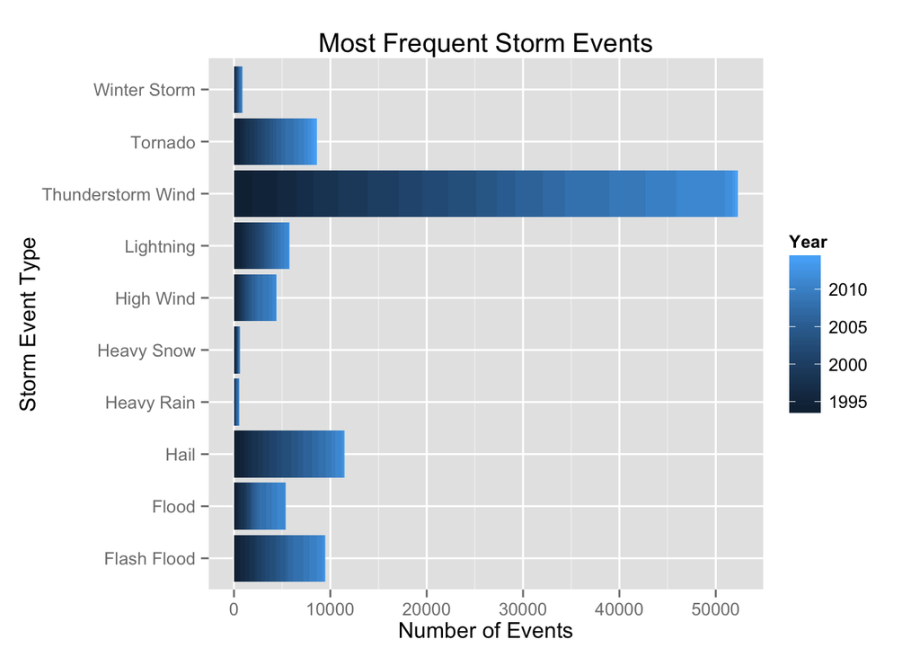

```r
t <- df %>%
    group_by(EVTYPE) %>%
    count(EVTYPE) %>%
    arrange(desc(n)) %>%
    top_n(10, n)
tevt <- t$EV

ev_df <- df %>%
    filter(EVTYPE %in% tevt) %>%
    group_by(year(BGN_DATE), EVTYPE) %>%
    summarise(num_evt = n()) %>%
    arrange(desc(num_evt)) %>%
    top_n(10, num_evt)

names(ev_df) <- c("year", "eventType", "num_evt")
hp0 <- ggplot(ev_df, aes(eventType, num_evt, fill = year)) +
    geom_bar(stat = 'identity', position = 'stack') +
    coord_flip() +
    scale_fill_continuous(name = "Year") +
    labs (title = "Most Frequent Storm Events"
          , x = "Storm Event Type"
          , y = "Number of Events")
print(hp0)
```

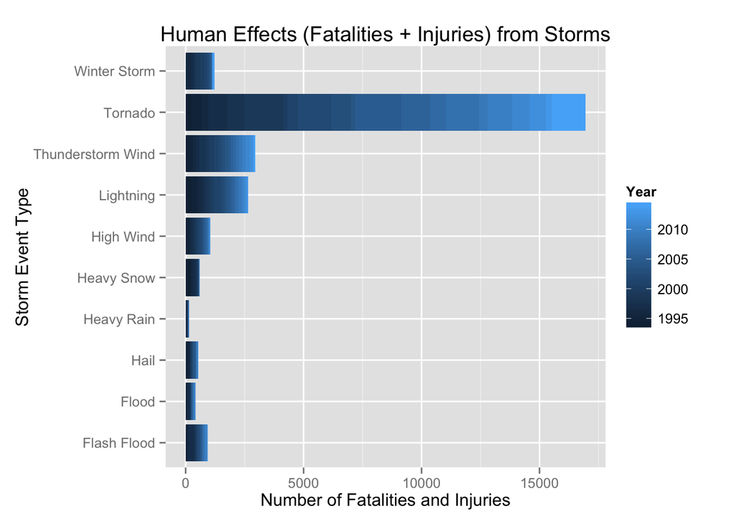

```r
th_df <- df %>%
    filter(EVTYPE %in% tevt) %>%
    group_by(year(BGN_DATE), EVTYPE) %>%
    summarise(sum_effect = sum(humEffect)) %>%
    arrange(desc(sum_effect)) %>%
    top_n(10, sum_effect)

names(th_df) <- c("year", "eventType", "sum_effect")
hp1 <- ggplot(th_df, aes(eventType, sum_effect, fill = year)) +
    geom_bar(stat = 'identity', position = 'stack') +
    coord_flip() +
    scale_fill_continuous(name = "Year") +
    labs (title = "Human Effects (Fatalities + Injuries) from Storms"
          , x = "Storm Event Type"
          , y = "Number of Fatalities and Injuries")
print(hp1)
```

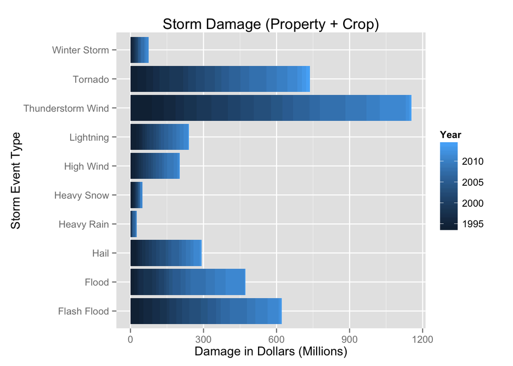

```r
td_df <- df %>%
    filter(EVTYPE %in% tevt) %>%
    group_by(year(BGN_DATE),EVTYPE) %>%
    summarise(sum_damage = sum(damage)) %>%
    arrange(desc(sum_damage)) %>%
    top_n(10, sum_damage)
names(td_df) <- c("year", "eventType", "sum_damage")

hp2 <- ggplot(td_df, aes(eventType, sum_damage/1000000, fill = year)) +
    geom_bar(stat = 'identity', position = 'stack') +
    coord_flip() +
    scale_fill_continuous(name = "Year") +
    labs (title = "Storm Damage (Property + Crop)"
          , x = "Storm Event Type"
          , y = "Damage in Dollars (Millions)")
print(hp2)
```